# Желтое такси в Нью-Йорке

*Задача этого проекта — научиться предсказывать количество поездок в ближайшие часы в каждом районе Нью-Йорка. Для того, чтобы её решить, сырые данные необходимо агрегировать по часам и районам. Агрегированные данные будут представлять собой почасовые временные ряды с количествами поездок из каждого района. Похожие задачи возникают на практике, если вам необходимо спрогнозировать продажи большого количества товаров в большом количестве магазинов, объём снятия денег в сети банкоматов, посещаемость разных страниц сайта и т.д.*

# Неделя 1: Знакомство с данными и агрегация

### 0. Вступление и подготовка к работе

Авторы проекта предложили использовать инструмент на выбор. Т.к. для меня это второй проект, то я решил его сделать на R. Ввиду того, что в специализации используется Python, то в основном тексте будет немного когда, чтобы лишний раз не раздражать ревьювера. Я постарался снабдить код комментариями, чтобы (при желании) легче было разобраться, а полный код используемых функций доступен в конце этого ноутбука.

Для работы потребуются следующие библиотеки и файлы:

```r
library(lubridate) # работа с датами
library(ggplot2) # графики
library(ggmap) # геоданные с Гугла
library(magrittr) # c'est ne pas une pipe

library(data.table) # работа с таблицами данных

source('helpers01.R') # здесь вспомогательные функции

# Sys.setlocale('LC_ALL','utf-8') # если неверно отображается кириллица
```

### 1. Загрузите данные за май 2016 года

```r
regions <- fread('data_in/regions.csv') # данные о регионах

dt_month <- fread('data_in/yellow_tripdata_2016-05.csv') # поездки в мае
# Read 11836853 rows and 19 (of 19) columns from 1.731 GB file in 00:00:49
```

Таблица с регионами:

```r
head(regions)
```

```
##    region      west      east    south    north
## 1:      1 -74.25559 -74.24448 40.49612 40.50451
## 2:      2 -74.25559 -74.24448 40.50451 40.51290
## 3:      3 -74.25559 -74.24448 40.51290 40.52128
## 4:      4 -74.25559 -74.24448 40.52128 40.52967
## 5:      5 -74.25559 -74.24448 40.52967 40.53806
## 6:      6 -74.25559 -74.24448 40.53806 40.54645
```

Таблица с данными о поездках имеет следующую структуру:

```r
# структура таблицы о поездках
str(dt_month)
```

```
## Classes 'data.table' and 'data.frame':   11836853 obs. of  19 variables:
##  $ VendorID             : int  1 2 2 2 2 2 2 2 2 2 ...
##  $ tpep_pickup_datetime : chr  "2016-05-01 00:00:00" "2016-05-01 00:00:00" "2016-05-01 00:00:00" "2016-05-01 00:00:00" ...
##  $ tpep_dropoff_datetime: chr  "2016-05-01 00:17:31" "2016-05-01 00:07:31" "2016-05-01 00:07:01" "2016-05-01 00:19:47" ...
##  $ passenger_count      : int  1 1 6 1 1 2 1 1 4 3 ...
##  $ trip_distance        : num  3.6 1.68 1.09 4.21 0.56 0.63 6.68 1.48 1.59 3.52 ...
##  $ pickup_longitude     : num  -74 -74 -74 -74 -74 ...
##  $ pickup_latitude      : num  40.8 40.7 40.7 40.7 40.7 ...
##  $ RatecodeID           : int  1 1 1 1 1 1 1 1 1 1 ...
##  $ store_and_fwd_flag   : chr  "N" "N" "N" "N" ...
##  $ dropoff_longitude    : num  -74 -74 -74 -74 -74 ...
##  $ dropoff_latitude     : num  40.7 40.8 40.7 40.7 40.7 ...
##  $ payment_type         : int  1 1 1 1 1 1 1 1 1 2 ...
##  $ fare_amount          : num  15 7.5 6.5 17 6 5 20.5 7 8 13 ...
##  $ extra                : num  0.5 0.5 0.5 0.5 0.5 0.5 0.5 0.5 0.5 0.5 ...
##  $ mta_tax              : num  0.5 0.5 0.5 0.5 0.5 0.5 0.5 0.5 0.5 0.5 ...
##  $ tip_amount           : num  1.5 0.88 1.56 3.66 1.46 0 2 1.66 0 0 ...
##  $ tolls_amount         : num  0 0 0 0 0 0 0 0 0 0 ...
##  $ improvement_surcharge: num  0.3 0.3 0.3 0.3 0.3 0.3 0.3 0.3 0.3 0.3 ...
##  $ total_amount         : num  17.8 9.68 9.36 21.96 8.76 ...
##  - attr(*, ".internal.selfref")=<externalptr>
```

### 2. Проведите фильтрацию

*Удалите поездки с:*

- *нулевой длительностью,*
- *нулевым количеством пассажиров,*
- *нулевым расстоянием поездки по счётчику,*
- *координатами начала, не попадающими в прямоугольник Нью-Йорка.*

Для очистки данных и рассчетов заведем переменную с константами о геоданных:

```r
##########################
# Константа с геоданными #
##########################

# Нью-Йорк вписан в прямоугольник от -74.25559 до -73.70001 градусов долготы и от 40.49612 до 40.91553 широты
NY <- list(lon = c(-74.25559, -73.70001), lat = c(40.49612, 40.91553))
NY$CELLS <- 50 # число ячеек по широте или долготе
NY$lon_step <- (NY$lon[2] - NY$lon[1]) / NY$CELLS # шаг по долготе
NY$lat_step <- (NY$lat[2] - NY$lat[1]) / NY$CELLS # шаг по широте
NY$lon_breaks <- seq(NY$lon[1], NY$lon[2], by = NY$lon_step) # границы регионов по долготе
NY$lat_breaks <- seq(NY$lat[1], NY$lat[2], by = NY$lat_step) # границы регионов по широте
```

Очистка и подготовка данных (код функций в приложении):

```r
dt_month <- make_durations(dt_month) # вводим длительность поездки (сек)
dt_month <- drop_0_duration(dt_month) # отбрасываем поездки с нулевой длительностью
dt_month <- drop_0_passenger_count(dt_month) # выбрасываем поездки без пассажирова
dt_month <- drop_0_trip_distance(dt_month) # убираем поездки с нулеввым расстоянием
dt_month <- drop_out_of_NY(dt_month) # исключаем поездки с посадкой вне Нью-Йорка
```

### 3. Агрегируйте данные за май 2016 года по часам и областям

*Не забудьте проверить, что идентификаторы, которые вы присваиваете ячейкам, соответствуют приложенному выше файлу.*

[output not shown]

Таким образом, `номер региона = (#LON - 1)*50 + #LAT`

```r
# чтобы не было вывода используется присваивание <-
# добавим каждому региону центр ячейки
regions <- regions[, `:=`(lon_mid = (east + west) / 2,
                          lat_mid = (south + north) / 2)]

# для центра каждой ячейки посчитаем регион функцией (в поле my_region)
regions <- regions[, my_region := get_region(lon_mid, lat_mid)]

# проверим, что все регионы совпадают
all(regions[, region == my_region]) # аее!
```

```
## [1] TRUE
```

```r
# можно посмотреть на начало и конец таблички
# (только столбцы: region, lon_mid, lat_mid, my_region)
regions[, .(region, lon_mid, lat_mid, my_region)]
```

```
##       region   lon_mid  lat_mid my_region
##    1:      1 -74.25003 40.50031         1
##    2:      2 -74.25003 40.50870         2
##    3:      3 -74.25003 40.51709         3
##    4:      4 -74.25003 40.52548         4
##    5:      5 -74.25003 40.53387         5
##   ---
## 2496:   2496 -73.70557 40.87778      2496
## 2497:   2497 -73.70557 40.88617      2497
## 2498:   2498 -73.70557 40.89456      2498
## 2499:   2499 -73.70557 40.90295      2499
## 2500:   2500 -73.70557 40.91134      2500
```

Теперь можно присвоить регионы всем строкам исходных данных о поездках:

```r
dt_month <- make_regions(dt_month)

# посмотрим хвостик таблицы
tail(dt_month[, .(VendorID, tpep_pickup_datetime, passenger_count, region)])
```

```
##    VendorID tpep_pickup_datetime passenger_count region
## 1:        2  2016-05-31 23:59:58               2   1384
## 2:        2  2016-05-31 23:59:58               6   1232
## 3:        2  2016-05-31 23:59:58               1   1234
## 4:        2  2016-05-31 23:59:58               1   1129
## 5:        1  2016-05-31 23:59:59               1   1285
## 6:        1  2016-05-31 23:59:59               2   1281
```

Затем сагрегируем данные по паре час-ячейка для каждого дня. Для регионов из которых не было поездок значение равно 0.

```r
dt_agg <- get_dt_agg_with_zeroes(dt_month)
```

### 4. Выведите первые строки полученной таблицы

```r
# первые строки агрегированной таблицы
head(dt_agg)
```

```
##    year month day hour region n
## 1: 2016     5   1    0      1 0
## 2: 2016     5   1    0      2 0
## 3: 2016     5   1    0      3 0
## 4: 2016     5   1    0      4 0
## 5: 2016     5   1    0      5 0
## 6: 2016     5   1    0      6 0
```

```r
# ячейка с максимальным числом поездок
dt_agg[n == max(n)]
```

```
##    year month day hour region    n
## 1: 2016     5   3   20   1282 2206
```

### 5. Постройте график количества поездок жёлтого такси из ячейки, содержащей Empire State Building

```r
# так можно узнать координаты Empire State Building
# ESB <- as.list(geocode('Empire State Building'))

# на случай, если нет подключения, введем координаты вручную
ESB <- list(lon = -73.98566, lat = 40.74844)

# вычислим регион для Empire State Building и посмотрим на него
ESB$region <- get_region(ESB$lon, ESB$lat)
ESB$region
```

```
## [1] 1231
```

```r
# вытащим из агрегированной таблицы данные только по нашему региону
dt_ESB <- dt_agg[region == ESB$region]
dt_ESB <- dt_ESB[, date := paste(year, month, day, hour) %>% ymd_h]

# выведем табличку
dt_ESB
```

```
##      year month day hour region    n                date
##   1: 2016     5   1    0   1231  881 2016-05-01 00:00:00
##   2: 2016     5   1    1   1231  713 2016-05-01 01:00:00
##   3: 2016     5   1    2   1231  533 2016-05-01 02:00:00
##   4: 2016     5   1    3   1231  418 2016-05-01 03:00:00
##   5: 2016     5   1    4   1231  353 2016-05-01 04:00:00
##  ---
## 740: 2016     5  31   19   1231 1094 2016-05-31 19:00:00
## 741: 2016     5  31   20   1231  997 2016-05-31 20:00:00
## 742: 2016     5  31   21   1231 1099 2016-05-31 21:00:00
## 743: 2016     5  31   22   1231  874 2016-05-31 22:00:00
## 744: 2016     5  31   23   1231  608 2016-05-31 23:00:00
```

Построим график количества поездок из таблички `1231`:

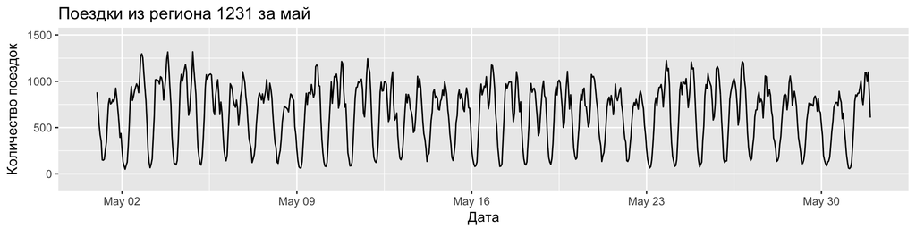

```r
ggplot(dt_ESB, aes(date, n)) + geom_line() +
    ylim(-100, 1500) +
    labs(title = "Поездки из региона 1231 за май", x = "Дата",
         y = "Количество поездок")
```

### 6. Посчитайте, сколько в мае 2016 было пар час-ячейка, для которых не было совершено ни одной поездки

Большинство пар час-ячейка нулевые:

```r
# количество нулевых ячеек
dt_agg[n == 0, .N]
```

```
## [1] 1718238
```

```r
# всего ячеек:
31 * 24 * 2500
```

```
## [1] 1860000
```

### 7. Публикация ноутбука и сохранение данных

Сохраним полученную таблицу агрегированных данных:

```r
fwrite(dt_agg, 'data_out/2016_05.csv')
```

Ноутбук опубликован на [rstudioconnect.com](https://beta.rstudioconnect.com/content/2211/taxi01.html). Файлы проекта также можно найти и на [гитхабе](https://github.com/yurkai/taxi).

### 8. Приложение: код функций

Здесь приведен код использовавшихся функций.

##### 8.1 make_durations

```r
# вводим новый признак -- продолжительность поездки
make_durations <- function(dt){
    # время посадки высадки -- character
    dt[,`:=`(
      tpep_pickup_datetime = parse_date_time(tpep_pickup_datetime, "YmdHMS"),
      tpep_dropoff_datetime = parse_date_time(tpep_dropoff_datetime, "YmdHMS"))]
    dt[, duration := as.numeric(tpep_dropoff_datetime - tpep_pickup_datetime,
                                units = "secs")]
    setkey(dt, tpep_pickup_datetime)

    dt
}
```

##### 8.2 drop_0_duration

```r
# удалить строки с duration == 0
drop_0_duration <- function(dt){
    dt[duration != 0]
}
```

##### 8.3 drop_0_passenger_count

```r
# удалить строки с passenger_count == 0
drop_0_passenger_count <- function(dt){
    dt[passenger_count != 0]
}
```

##### 8.4 drop_0_trip_distance

```r
# удалить строки с trip_distance == 0
drop_0_trip_distance <- function(dt){
    dt[trip_distance != 0]
}
```

##### 8.5 drop_out_of_NY

```r
# удалить строки с координатами начала, не попадающими в прямоугольник Нью-Йорка
drop_out_of_NY <- function(dt){
    dt[pickup_longitude >= NY$lon[1] & pickup_longitude <= NY$lon[2] &
       pickup_latitude >= NY$lat[1] & pickup_latitude <= NY$lat[2]]
}
```

##### 8.6 get_region

```r
# определение ячейки по координатам
get_region <- function(lon, lat){
    lon_cell <- findInterval(lon, NY$lon_breaks, rightmost.closed=TRUE)
    lat_cell <- findInterval(lat, NY$lat_breaks, rightmost.closed=TRUE)

    (lon_cell - 1) * NY$CELLS + lat_cell
}
```

##### 8.7 make_regions

```r
# проставить регион для всех данных
make_regions <- function(dt){
    dt[, region := get_region(pickup_longitude, pickup_latitude)]
}
```

##### 8.8 get_dt_agg_with_zeroes

```r
# табличка агрегированных данных
get_dt_agg_with_zeroes <- function(dt){
    # добавим час и день (потом еще надо будет месяц)
    dt[, `:=`(day = mday(tpep_pickup_datetime),
                    hour = hour(tpep_pickup_datetime))]
    first_date <- dt[1, tpep_pickup_datetime]

    # узнаем есть ли пропуски по датам
    days <- days_in_month(first_date) %>% seq_len
    missing_days <- setdiff(days, dt[, unique(day)]) # паранойя
    if (length(missing_days) > 0){
        # добавляем эти дни в данные
        dt_missing <- data.table(region = 1, day = missing_days, hour = 0)
        dt <- rbindlist(list(dt, dt_missing), fill = TRUE)
    }

    # узнаем есть ли пропуски по часам
    missing_hours <- setdiff(1:23, dt[, unique(hour)]) # еще паранойя
    if (length(missing_hours) > 0){
        dt_missing <- data.table(region = 1, day = 1, hour = missing_hours)
        dt <- rbindlist(list(dt, dt_missing), fill = TRUE)
    }

    # узнаем есть ли пропуски по регионам
    missing_regions <- setdiff(seq_len(nrow(regions)), dt[, unique(region)])
    if (length(missing_regions) > 0){
        dt_missing <- data.table(region = missing_regions, day = 1, hour = 0)
        dt <- rbindlist(list(dt, dt_missing), fill = TRUE)
    }

    # делаем сводную
    setkey(dt, day, hour, region)
    dt_agg <- dt[CJ(day, hour, region, unique = TRUE), .(n = .N), by = .EACHI]
    # надо обнулить частоты для искусственно введенных значений
    dt_agg[(day %in% missing_days) |
           (hour %in% missing_hours) |
           (region %in% missing_regions), n := 0]

    # и еще паранойя
    # можно проверить, что добавляем все правильно:
    # никаких левых данных мы не записали
    # dt_agg[(region %in% missing_regions), unique(region)] %>%
    #     setdiff(., missing_regions)
    #
    # количество строк правильное: дней_в_месяце * часов_в_дне * число_регионов
    # nrow(dt_agg) ==
    #     nrow(regions) * days_in_month(dt[1, tpep_pickup_datetime]) * 24

    # добавляем месяц в получившуюся таблицу
    dt_agg[, `:=`(month = month(first_date),
                  year = year(first_date))]

    # устанавливаем красивый порядок колонок
    setcolorder(dt_agg, c('year', 'month', 'day','hour', 'region', 'n'))

    # если не жалко время, можно вернуть данные к исходному числу строк
    # dt <- dt[!((day %in% missing_days) |
    #                            (hour %in% missing_hours) |
    #                            (region %in% missing_regions))]
    # dt[,`:=`(day = NULL, hour = NULL)]

    dt_agg
}
```